# Comparative Analysis of Generalized Kumaraswamy Family Distributions

07 abril, 2025

## Executive Summary

This report presents a comparative analysis of Generalized Kumaraswamy (GKw) family distributions fitted to the data. The analysis includes comparison of information criteria, goodness-of-fit tests, and diagnostic visualizations.

### Key Findings

- **Best Model**: ekw
- **Total Observations**: 52
- **AIC Value of Best Model**: -65.53
- **BIC Value of Best Model**: -59.68

## Descriptive Statistics of the Data

| Statistic | Value |
| --- | --- |
| Minimum | 0.2693 |
| First Quartile | 0.3545 |
| Median | 0.4310 |
| Mean | 0.4571 |
| Third Quartile | 0.5244 |
| Maximum | 0.7904 |
| Standard Deviation | 0.1291 |
| Skewness | 0.7364 |
| Kurtosis | 2.7163 |

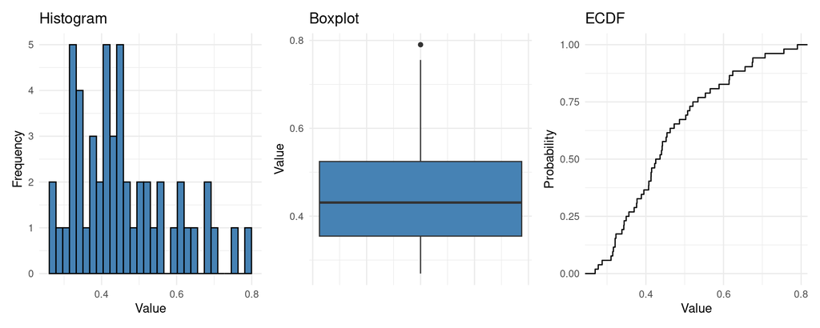

## Model Comparison

### Information Criteria

|  | Family | Parameters | Log-Likelihood | AIC | BIC | AICc |
| --- | --- | --- | --- | --- | --- | --- |
| ekw | ekw | 3 | 35.7671 | -65.5342 | -59.6805 | -65.0342 |
| beta | beta | 2 | 33.5543 | -63.1087 | -59.2062 | -62.8638 |
| bkw | bkw | 4 | 35.3945 | -62.7890 | -54.9840 | -61.9380 |
| kkw | kkw | 4 | 35.3491 | -62.6982 | -54.8932 | -61.8471 |
| gkw | gkw | 5 | 35.9450 | -61.8901 | -52.1338 | -60.5857 |
| mc | mc | 3 | 33.5791 | -61.1583 | -55.3045 | -60.6583 |
| kw | kw | 2 | 31.2291 | -58.4583 | -54.5558 | -58.2134 |

### Model Weights

|  | Family | AIC Weight | BIC Weight |
| --- | --- | --- | --- |
| ekw | ekw | 0.4771 | 0.4570 |
| beta | beta | 0.1419 | 0.3606 |
| bkw | bkw | 0.1209 | 0.0437 |
| kkw | kkw | 0.1156 | 0.0417 |
| gkw | gkw | 0.0771 | 0.0105 |
| mc | mc | 0.0535 | 0.0513 |
| kw | kw | 0.0139 | 0.0352 |

### Goodness-of-Fit Tests

|  | Family | KS Statistic | KS p-value | AD Statistic | AD p-value | CvM Statistic | CvM p-value |
| --- | --- | --- | --- | --- | --- | --- | --- |
| ekw | ekw | 0.0923 | 0.7328 | 0.5438 | 0.5423 | 0.0827 | 0.7726 |
| beta | beta | 0.1247 | 0.3633 | 0.9532 | 0.2007 | 0.1606 | 0.6872 |
| bkw | bkw | 0.0953 | 0.6964 | 0.5792 | 0.4975 | 0.0887 | 0.7647 |
| kkw | kkw | 0.0951 | 0.6984 | 0.5781 | 0.4988 | 0.0885 | 0.7650 |
| gkw | gkw | 0.0842 | 0.8244 | 0.4801 | 0.6340 | 0.0703 | 0.7900 |
| mc | mc | 0.1237 | 0.3734 | 0.9362 | 0.2090 | 0.1573 | 0.6903 |
| kw | kw | 0.1373 | 0.2564 | 1.2759 | 0.0925 | 0.2150 | 0.6413 |

### Additional Fit Metrics

|  | Family | Mean Absolute Error | Maximum Absolute Error | Mean Squared Error | Wasserstein Distance |
| --- | --- | --- | --- | --- | --- |
| 1 | gkw | 0.034639 | 0.084213 | 0.001674 | 0.018729 |
| 4 | ekw | 0.037352 | 0.092283 | 0.001958 | 0.019935 |
| 3 | kkw | 0.038562 | 0.095146 | 0.002082 | 0.020537 |
| 2 | bkw | 0.038623 | 0.095309 | 0.002089 | 0.020554 |
| 5 | mc | 0.049706 | 0.123680 | 0.003564 | 0.026127 |
| 7 | beta | 0.050195 | 0.124724 | 0.003636 | 0.026362 |
| 6 | kw | 0.055093 | 0.137306 | 0.004669 | 0.030887 |

## Estimated Parameters

|  | Family | alpha | beta | gama | delta | lambda |
| --- | --- | --- | --- | --- | --- | --- |
| ekw | ekw | 0.8215 | 4.6537 | NA | NA | 20.0000 |
| beta | beta | NA | NA | 6.5653 | 6.7240 | NA |
| bkw | bkw | 0.7680 | 4.1097 | 20.0000 | 0.1555 | NA |
| kkw | kkw | 0.7637 | 4.1846 | NA | 0.1295 | 20.0000 |
| gkw | gkw | 0.3820 | 3.6567 | 10.2057 | 0.1412 | 10.1803 |
| mc | mc | NA | NA | 8.8418 | 6.6128 | 0.7899 |
| kw | kw | 3.5079 | 10.0188 | NA | NA | NA |

|  | Family | SE(alpha) | SE(beta) | SE(gama) | SE(delta) | SE(lambda) |
| --- | --- | --- | --- | --- | --- | --- |
| ekw | ekw | 0.1358 | 0.7958 | NA | NA | 1.1025 |
| beta | beta | NA | NA | 1.2673 | 1.4997 | NA |
| bkw | bkw | 0.1605 | 1.1468 | 1.1703 | 0.3059 | NA |
| kkw | kkw | 0.1623 | 1.0359 | NA | 0.2433 | 1.1286 |
| gkw | gkw | 0.3642 | 0.9499 | 25.5246 | 0.2695 | 25.4890 |
| mc | mc | NA | NA | 12.4356 | 1.5338 | 0.8893 |
| kw | kw | 0.4050 | 2.7908 | NA | NA | NA |